# Упражнение 9

Владимиров Андрей

09 05 2021

Необходимо построить модель на основе SVM для указанной в варианте зависимой переменной.

Данные взять из упражнения №3.

Для модели:

- Отложить 25% наблюдений в тестовую выборку (ядро генератора случайных чисел указано в варианте к упражнению №3).
- На обучающей выборке (оставшихся 75% наблюдений) сравнить несколько видов ядер SVM по точности модели (AUC) методом сеточного поиска.
- Для оптимальной формы ядерной функции на обучающей выборке подобрать оптимальное значение настроечных параметров по минимальной ошибке с перекрёстной проверкой (функция tune).
- Подогнать лучшую модель на всей обучающей выборке. Построить ROC-кривую и рассчитать матрицу неточностей, чувствительность и специфичность.
- Сделать прогноз по лучшей модели на тестовую выборку, оценить его качество точность по матрице неточностей, чувствительность и специфичность, построить ROC-кривую.
- Сравнить результаты, которые дал SVM, с результатами, полученными в упражнении 3. Какой из методов оказался лучше?

## Вариант8

- Ядро для *set.seed() - 234*.
- Данные: *Glass{mlbench}* - химический состав разных типов стекла.
- Зависимая переменная: *Type 1* (1 – наличие признака, все остальные – отсутствие).
- Объясняющие переменные: Все остальные.
- Методы: *Логистическая регрессия, QDA*.

```r
my.seed <-  234       # ядро генерации
train.percent <- 0.75 # доля обучающей выборки

data(Glass)
head(Glass)
```

```
##        RI    Na   Mg   Al    Si    K   Ca Ba   Fe Type
## 1 1.52101 13.64 4.49 1.10 71.78 0.06 8.75  0 0.00    1
## 2 1.51761 13.89 3.60 1.36 72.73 0.48 7.83  0 0.00    1
## 3 1.51618 13.53 3.55 1.54 72.99 0.39 7.78  0 0.00    1
## 4 1.51766 13.21 3.69 1.29 72.61 0.57 8.22  0 0.00    1
## 5 1.51742 13.27 3.62 1.24 73.08 0.55 8.07  0 0.00    1
## 6 1.51596 12.79 3.61 1.62 72.97 0.64 8.07  0 0.26    1
```

```r
Type1 <- rep(0, length(Glass$Type)) # Создание вектора Type1
Glass <- cbind(Glass, Type1)        # Присоединение Type1 к фрейму Glass

# Замена в переменной Type: если Type = 1 означает наличие признака (1), остальные - отсутствие(0)
for(i in 1:length(Glass$Type)) {if (Glass$Type[i] == 1) {Glass$Type1[i] = 1}}

# Определение долей
table(Glass$Type1) / sum(table(Glass$Type1))
```

```
##
##         0         1
## 0.6728972 0.3271028
```

# Сеточный поиск

```r
# Отбираем наблюдения в обучающую выборку
set.seed(my.seed)
inTrain <- sample(seq_along(Glass$Type1),
                  nrow(Glass)*train.percent)
xtrain <- Glass[inTrain, c(-10, -11)]
xtest <- Glass[-inTrain, c(-10, -11)]
ytrain <- Glass[inTrain, 11]
ytest <- Glass[-inTrain, 11]

# Обучающая выборка
dat <- data.frame(x = xtrain, y = as.factor(ytrain))

# Тестовые данные
dat.te <- data.frame(x = xtest, y = as.factor(ytest))

# Параметры алгоритма
kernel.grid <- c('linear', 'polynomial')
cost.grid <- seq(1, 20, by = 0.5)

AUC <- matrix(0, length(kernel.grid), length(cost.grid))
colnames(AUC) <- paste0('cost = ', cost.grid)
rownames(AUC) <- paste0('kernel = ', kernel.grid)

# SVM
for (i in 1:length(kernel.grid)) {
    print(paste0('Starting ', kernel.grid[i], ' kernel'))
    for (j in 1:length(cost.grid)) {
        out <- svm(y ~ ., data = dat, kernel = kernel.grid[i],
                   cost = cost.grid[j])
        # Прогноз на тестовой выборке
        pred.te <- predict(out, newdata = dat.te)
        # Матрица неточностей
        tbl <- table(pred.te, dat.te$y)
        AUC[i, j] <- sum(diag(tbl)) / sum(tbl)
    }
}
```

```
## [1] "Starting linear kernel"
## [1] "Starting polynomial kernel"
```

```r
round(AUC, 3)
```

```
##                     cost = 1 cost = 1.5 cost = 2 cost = 2.5 cost = 3 cost = 3.5
## kernel = linear        0.796      0.796    0.796      0.796    0.796      0.796
## kernel = polynomial    0.741      0.741    0.759      0.759    0.759      0.759
##                     cost = 4 cost = 4.5 cost = 5 cost = 5.5 cost = 6 cost = 6.5
## kernel = linear        0.796      0.796    0.796      0.796    0.796      0.796
## kernel = polynomial    0.759      0.759    0.759      0.759    0.759      0.759
##                     cost = 7 cost = 7.5 cost = 8 cost = 8.5 cost = 9 cost = 9.5
## kernel = linear        0.796      0.796    0.796      0.796    0.796      0.796
## kernel = polynomial    0.759      0.759    0.741      0.741    0.741      0.741
##                     cost = 10 cost = 10.5 cost = 11 cost = 11.5 cost = 12
## kernel = linear         0.796       0.796     0.796       0.796     0.796
## kernel = polynomial     0.759       0.759     0.759       0.759     0.778
##                     cost = 12.5 cost = 13 cost = 13.5 cost = 14 cost = 14.5
## kernel = linear           0.796     0.796       0.796     0.796       0.796
## kernel = polynomial       0.796     0.796       0.796     0.796       0.796
##                     cost = 15 cost = 15.5 cost = 16 cost = 16.5 cost = 17
## kernel = linear         0.796       0.796     0.796       0.796     0.796
## kernel = polynomial     0.796       0.796     0.796       0.796     0.815
##                     cost = 17.5 cost = 18 cost = 18.5 cost = 19 cost = 19.5
## kernel = linear           0.796     0.796       0.796     0.796       0.796
## kernel = polynomial       0.815     0.815       0.796     0.778       0.778
##                     cost = 20
## kernel = linear         0.796
## kernel = polynomial     0.778
```

```r
# Классификатор на опорных векторах
svmfit <- svm(y ~ ., data = dat, kernel = "linear", cost = 6, cale = FALSE)

# Список опорных векторов
svmfit$index
```

```
##  [1]   1   2   5  10  11  12  14  17  18  20  23  26  29  42  43  55  62  66  68
## [20]  72  82  86  88  89  92  94  96 101 110 111 112 113 121 122 125 127 131 140
## [39] 148 150 156  13  15  19  22  25  27  28  31  33  36  37  38  41  49  50  64
## [58]  65  67  69  70  74  75  77  78  91  93  95  97  98  99 106 108 117 120 128
## [77] 129 133 138 141 142 146 149 152 153 155 158
```

```r
# Сводка по модели
summary(svmfit)
```

```
##
## Call:
## svm(formula = y ~ ., data = dat, kernel = "linear", cost = 6, cale = FALSE)
##
##
## Parameters:
##    SVM-Type:  C-classification
##  SVM-Kernel:  linear
##        cost:  6
##
## Number of Support Vectors:  87
##
##  ( 41 46 )
##
##
## Number of Classes:  2
##
## Levels:
##  0 1
```

```r
# Делаем перекрёстную проверку, изменяя штраф (аргумент cost)
# Делаем перекрёстную проверку, изменяя штраф (аргумент cost)
set.seed(my.seed)
tune.out <- tune(svm, y ~ ., data = dat, kernel = "linear",
                 ranges = list(cost = c(0.001, 0.1, 1, 5, 10, 100)))
summary(tune.out)
```

```
##
## Parameter tuning of 'svm':
##
## - sampling method: 10-fold cross validation
##
## - best parameters:
##  cost
##     5
##
## - best performance: 0.2375
##
## - Detailed performance results:
##    cost   error dispersion
## 1 1e-03 0.32500 0.09682458
## 2 1e-01 0.36875 0.12655285
## 3 1e+00 0.26875 0.11429889
## 4 5e+00 0.23750 0.11711224
## 5 1e+01 0.25625 0.11949692
## 6 1e+02 0.28125 0.11505584
```

# Лучшая модель на всей обучающей выборке

```r
# Лучшая модель -- с минимальной ошибкой
bestmod <- tune.out$best.model
summary(bestmod)
```

```
##
## Call:
## best.tune(method = svm, train.x = y ~ ., data = dat, ranges = list(cost = c(0.001,
##     0.1, 1, 5, 10, 100)), kernel = "linear")
##
##
## Parameters:
##    SVM-Type:  C-classification
##  SVM-Kernel:  linear
##        cost:  5
##
## Number of Support Vectors:  86
##
##  ( 41 45 )
##
##
## Number of Classes:  2
##
## Levels:
##  0 1
```

```r
# Делаем прогноз по лучшей модели
ypred_tr <- predict(bestmod, dat)

# Матрица неточностей
tbl1 <- table(Predicts = ypred_tr, Fact = dat$y)
tbl1
```

```
##         Fact
## Predicts  0  1
##        0 95 20
##        1 13 32
```

```r
# Чувствительность
TPR <- round(tbl1[2,2]/sum(tbl1[2,]),3)
TPR
```

```
## [1] 0.711
```

```r
# Специфичность
SPC <- round(tbl1[1,1]/sum(tbl1[1,]),3)
SPC
```

```
## [1] 0.826
```

```r
# Функция построения ROC-кривой: pred -- прогноз, truth -- факт
rocplot <- function(pred, truth, ...){
    predob = prediction(pred, truth)
    perf = performance(predob, "tpr", "fpr")
    plot(perf,...)}

# Оптимальная модель
svmfit.opt <- svm(y ~ ., data = dat, kernel = "linear",  cost = 10, probability = T)

# Матрица неточностей на обучающей (p = 0.01)
table(Predicts = predict(svmfit.opt, dat),
             Fact = dat$y)
```

```
##         Fact
## Predicts  0  1
##        0 96 21
##        1 12 31
```

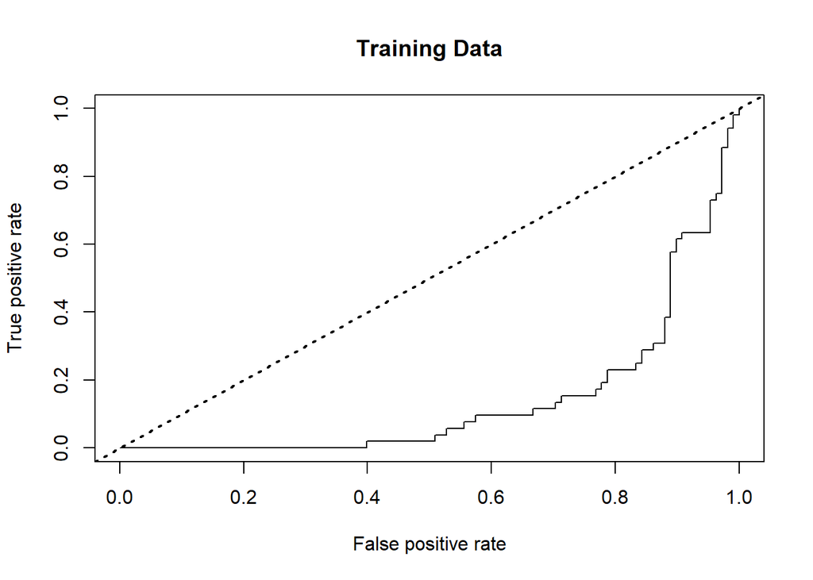

```r
# Прогноз вероятностей, на основе которых присваивается класс
fitted.prob <- predict(svmfit.opt, dat, type = "prob",  probability = TRUE)
fitted.prob <- attr(fitted.prob, "probabilities")[, 2]

# График для обучающей выборки
# ROC-кривая для первой модели
rocplot(fitted.prob, dat[, "y"], main = "Training Data")
# Прямая случайного классификатора
abline(a = 0, b = 1, lty = 3, lwd = 2)
```

# Лучшая модель на тестовой выборке

```r
# График для тестовой выборки
fitted.prob <- predict(svmfit.opt, dat.te, type = "prob",
                       probability = TRUE)
fitted.prob <- attr(fitted.prob, "probabilities")[, 2]

# Матрица неточностей на тестовой (p = 0.01)
tbl2 <- table(Predicts = predict(svmfit.opt, dat.te), Fact = dat.te$y)
tbl2
```

```
##         Fact
## Predicts  0  1
##        0 32  7
##        1  4 11
```

```r
# Точность
ACC <- round(sum(diag(tbl2))/sum(tbl2),3)
ACC
```

```
## [1] 0.796
```

```r
# Чувствительность
TPR <- round(tbl2[2,2]/sum(tbl2[2,]),3)
TPR
```

```
## [1] 0.733
```

```r
# Специфичность
SPC <- round(tbl2[1,1]/sum(tbl2[1,]),3)
SPC
```

```
## [1] 0.821
```

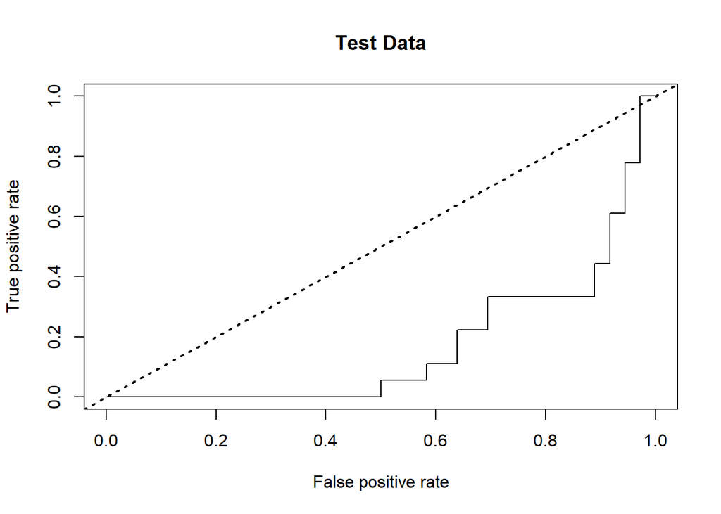

```r
# ROC-кривая для тестовой выборки
rocplot(fitted.prob, dat.te$y, main = "Test Data")
# Прямая случайного классификатора
abline(a = 0, b = 1, lty = 3, lwd = 2)
```

Как видно из графиков ROC-кривых, и для обучающей, и для тестовой выборок значение AUC менее 0.5, а значит классификатор действует с точностью до наоборот: если положительные классификации назвать отрицательными и наоборот, классификатор будет работать лучше. Учтём это при сравнении моделей на тестовой выборке.